# t-Distribution

## Getting Brief About **t-Distribution**

To get help of *t-distribution*, we can simple write :

```r
help(pt)
```

or,

```r
?pt
```

### Calculating **p-Value** when **t-statistics** and **Sample Size(n)** are given :

Let’s say we are given :

*t-statistics* = 2.3 *Sample Size (n)* = 26

So,

*Degrees of freedom (df)* = n-1 = 25

#### Getting **One sided p-value** :

To get *p(t > 2.3)* :

```r
pt(q = 2.3, df = 25, lower.tail = FALSE)
```

```
## [1] 0.01503675
```

So, by the argument `lower.tail = FALSE`, we mean we want to find the the area after `t > 2.3`.

#### Getting **Two sided p-value** :

This is used to get the area above `t = 2.3` and below `t = -2.3`

To get this :

```r
pt(q=2.3, df=25, lower.tail = F) + pt(q=-2.3, df=25,lower.tail=T)
```

```
## [1] 0.03007351
```

Or,

```r
pt(q=2.3, df=25, lower.tail = F) * 2
```

```
## [1] 0.03007351
```

### Calculating **t-value** for 95% Confidence :

95% confidence implies the *p-value* in each tail as 2.5%

So, to find *t-statistics* when *p-value of each tail is 2.5%* :

```r
qt(p = 0.025, df = 25, lower.tail = T)
```

```
## [1] -2.059539
```

### One Sample t-Test

To perfrom a one sample t-Test, let’s first get the data :

```r
LungCapData = read.table(file = "Dataset/LungCapData.txt", header = T, sep = "\t")
```

Let’s see the variables present in our dataset :

```r
names(LungCapData)
```

```
## [1] "LungCap"   "Age"       "Height"    "Smoke"     "Gender"    "Caesarean"
```

```r
class(LungCapData$LungCap)
```

```
## [1] "numeric"
```

To get any additional help on *t-test* :

```r
help("t.test")
#or,
?t.test
```

Let’s visualize the data first :

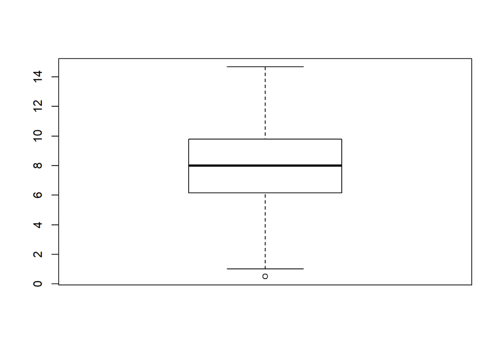

```r
boxplot(LungCapData$LungCap)
```

Let’s say,

Ho: mean = 8 Ha: mean < 8

Let’s perform the hypothesis testing

```r
t.test(LungCapData$LungCap, mu=8, alternative = "less", conf.level = 0.95)
```

```
##
##  One Sample t-test
##
## data:  LungCapData$LungCap
## t = -1.3842, df = 724, p-value = 0.08336
## alternative hypothesis: true mean is less than 8
## 95 percent confidence interval:
##      -Inf 8.025974
## sample estimates:
## mean of x
##  7.863148
```

The default t-test in R is two sided, so, if we not include the argument `alternative="less"` then, R will perform a two sided hypothesis test.

To see the attributes of the t-Test, we can store the test results in a variable and then pass the `attributes` function :

```r
Test = t.test(LungCapData$LungCap, mu=8, alternative = "less", conf.level = 0.95)
attributes(Test)
```

```
## $names
##  [1] "statistic"   "parameter"   "p.value"     "conf.int"    "estimate"
##  [6] "null.value"  "stderr"      "alternative" "method"      "data.name"
##
## $class
## [1] "htest"
```

To only see a specific attribute of the test :

```r
Test$conf.int
```

```
## [1]     -Inf 8.025974
## attr(,"conf.level")
## [1] 0.95
```

```r
Test$p.value
```

```
## [1] 0.08335542
```

### Paired T-Test

Let’s first get the data :

```r
BPData = read.table(file = "Dataset/BloodPressure.txt",header = T, sep = "\t")
```

Let’s see the data:

```r
names(BPData)
```

```
## [1] "Subject" "Before"  "After"
```

dimesion of the dataset is :

```r
dim(BPData)
```

```
## [1] 25  3
```

Let’s visualize the data :

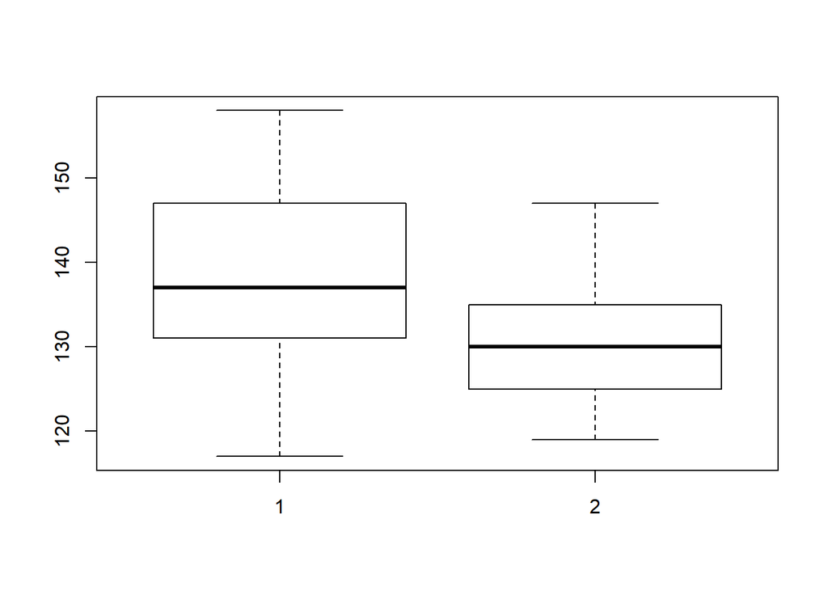

```r
attach(BPData)
boxplot(Before,After)
```

Let’s plot a scatter plot between the “Before” and “After” result to see a correlation between them :

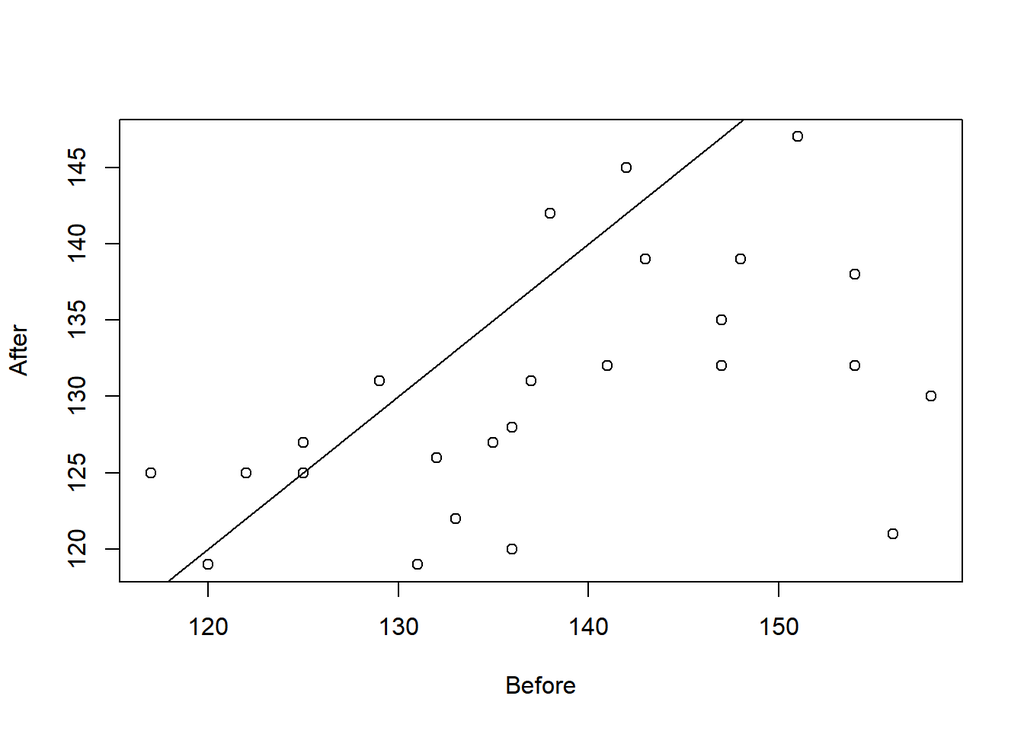

```r
plot(Before, After)
abline(a=0, b=1) #slope = 0 and intercept = 1
```

Let’s perform a two sided hypothesis test on our data :

Ho: Mean difference is zero, i.e., no chnage is SBP before and after Ha: Mean difference is not zero, i.e., there is a change is SBP

```r
t.test(Before, After, mu=0, alternative = "two.sided", paired = TRUE, conf.level = 0.99)
```

```
##
##  Paired t-test
##
## data:  Before and After
## t = 3.8882, df = 24, p-value = 0.0006986
## alternative hypothesis: true difference in means is not equal to 0
## 99 percent confidence interval:
##   2.245279 13.754721
## sample estimates:
## mean of the differences
##                       8
```

As the *p-Value* is very small, hence we reject the null hypothesis.

If we change the order of “Before” and “After” then, it will only change the sign of `mean if the differences`, `Confidence Interval` and `t-Statistics`.

### Independent Two Sample t-Test

- A parametric method appropriate for examining the difference in means for 2 populations.
- A way of examining the relationship between a numeric outcome variable (Y) and a categorical explanatory variable (X, with 2 levels)

We will be examining the relationship between the **Smoking Habits** and its effect on **Lung Capacity**.

Let’s see the class of these two variables first.

```r
class(LungCapData$LungCap)
```

```
## [1] "numeric"
```

```r
class(LungCapData$Smoke)
```

```
## [1] "factor"
```

Let’s visualize the data :

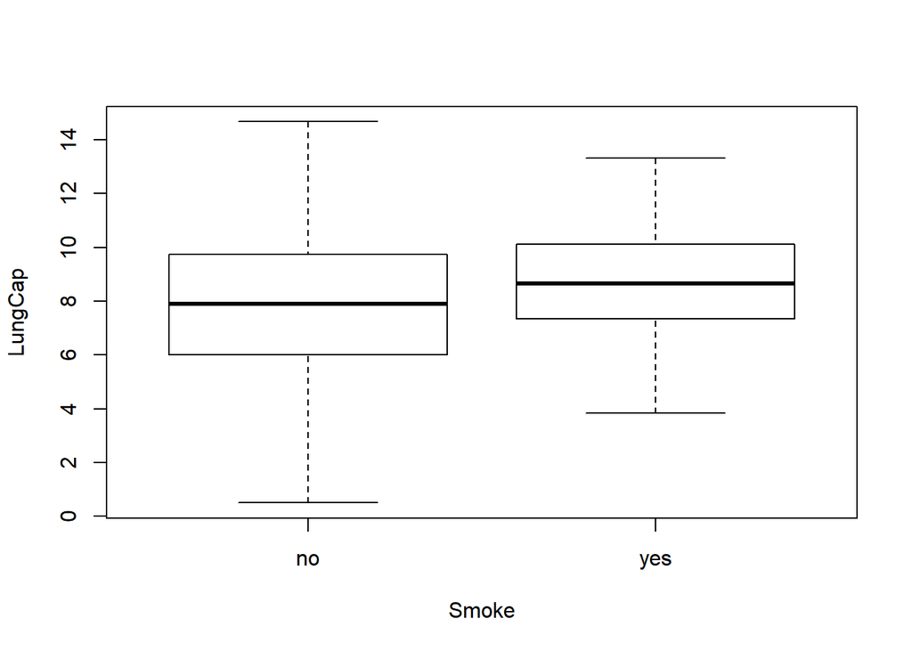

```r
attach(LungCapData)
boxplot(LungCap ~ Smoke)
```

Let’s perform a hypothesis test :

Ho: Mean Lung capcity of smokers and non-smokers are same Ha: Mean Lung capacity of smokers and non-smokers are different.

Let’s perform a two sided t-test -:

```r
t.test(LungCap ~ Smoke, mu=0, alt="two.sided", conf=0.95, var.eq=F, Paired=F )
```

```
##
##  Welch Two Sample t-test
##
## data:  LungCap by Smoke
## t = -3.6498, df = 117.72, p-value = 0.0003927
## alternative hypothesis: true difference in means is not equal to 0
## 95 percent confidence interval:
##  -1.3501778 -0.4003548
## sample estimates:
##  mean in group no mean in group yes
##          7.770188          8.645455
```

As the **p-Value** is small, so we reject the null hypothesis and thus, the mean lung capacity of smokers and non-smokers are different.

By the argument `var.eq=F`, we considered non-equal variance for the groups.

```r
var(LungCap[Smoke=="yes"])
```

```
## [1] 3.545292
```

```r
var(LungCap[Smoke=="no"])
```

```
## [1] 7.431694
```

We can clearly see that the variance in lung capacity for people who doesn’t smoke is almost double of those who smoke.

### Levene’s Test

This test is used to check whether the population variances are equal or, not.

So, let’s perform an hypothesis test on this.

Ho: Population variances are equal Ha: population variances are not equal

```r
library(car)
```

Let’s now perform the **Levene’s Test**

```r
leveneTest(LungCap~Smoke)
```

```
## Levene's Test for Homogeneity of Variance (center = median)
##        Df F value    Pr(>F)
## group   1  12.955 0.0003408 ***
##       723
## ---
## Signif. codes:  0 '***' 0.001 '**' 0.01 '*' 0.05 '.' 0.1 ' ' 1
```

From the above test, we can see :

*p-Value :* 0.00034 = 0.034%

As the *p-Value* is very small, so, we reject the null hypothesis and have evidence to believe that the population have unequal variances.